# Hábitos de sueño, consumo de bebidas energéticas y bienestar estudiantil en universitarios e institutos durante el ciclo 2026-I

Authors

Piero Max Ortiz Villafuerte (Líder)

Joel Modesto Cayllahua Hilario

Salvador Donayre Epifania

Sebastian Ernesto Chahuara Galdos

Marisol Yaranga Delgado

# 1 I. Introducción

## 1.1 I.1 Relevancia

El estilo de vida de los estudiantes universitarios y de institutos se encuentra estrechamente relacionado con factores que afectan su salud física y mental. El consumo de bebidas energéticas ha aumentado considerablemente debido a las exigencias académicas y hábitos de descanso irregulares, siendo usadas como alternativa para mantenerse despiertos y mejorar la concentración. Sin embargo, su consumo frecuente puede generar efectos negativos sobre la calidad del sueño y el nivel de estrés. Analizar la relación entre el consumo de bebidas energéticas y el bienestar estudiantil es relevante para identificar patrones que permitan orientar estrategias de salud en la comunidad académica.

## 1.2 I.2 Objetivos

### 1.2.1 I.2.1 Objetivo general

Analizar la relación entre el consumo de bebidas energéticas y los hábitos de sueño, actividad física y bienestar general de estudiantes universitarios y de institutos durante el ciclo académico 2026-I mediante herramientas de análisis estadístico y probabilístico.

### 1.2.2 I.2.2 Objetivos específicos

- Determinar la relación entre la frecuencia de consumo de bebidas energéticas y las horas de sueño diarias de los estudiantes durante el ciclo académico 2026-I.
- Analizar la relación entre el nivel de estrés autopercibido y la calidad de sueño reportada por los estudiantes durante el ciclo académico 2026-I.

# 2 II. Contexto

## 2.1 II.1 Población objetivo

La población objetivo está conformada por estudiantes universitarios y de institutos matriculados durante el ciclo académico 2026-I. La unidad muestral corresponde a cada estudiante participante en la encuesta, representando una observación individual. Se buscó representatividad incluyendo estudiantes de diferentes centros de estudio, carreras y ciclos académicos.

## 2.2 II.2 Tipo de muestreo

Se utilizó un muestreo no probabilístico por conveniencia, dado que los participantes fueron seleccionados según su accesibilidad y disposición para responder la encuesta virtual. Este tipo de muestreo permite obtener información de manera eficiente, con la limitación de no poder generalizar con certeza estadística a toda la población.

## 2.3 II.3 Recolección de datos

Los datos se recolectaron mediante una encuesta virtual en Google Forms distribuida a través de redes sociales y grupos académicos durante el ciclo 2026-I. Es una fuente de datos **primaria**. Toda la información fue obtenida por autorreporte. La muestra efectiva utilizada en este informe es de **n = 1192 observaciones limpias** de toda la sección.

## 2.4 II.4 Variables

| Variable | Tipo | Restricción |
| --- | --- | --- |
| Edad | Cuantitativa discreta | [17, 25] años |
| Sexo | Cualitativa nominal | Masculino / Femenino |
| HorasSuenio | Cuantitativa continua | [3, 12] horas |
| HorasEjercicio | Cuantitativa continua | [0, 20] horas |
| FrecBebida | Cuantitativa discreta | [0, 7] días/semana |
| UnidadBebida | Cuantitativa discreta | [0, 5] unidades/día |
| CalidadSuenio | Cualitativa ordinal | Muy mala → Muy buena |
| Estres | Cualitativa ordinal | Nulo → Muy alto |
| ActividadFisica | Cualitativa nominal | 5 categorías |
| Carrera | Cualitativa nominal | 6 áreas |
| CantidadCursos | Cuantitativa discreta | [3, 8] cursos |
| CicloAcademico | Cualitativa ordinal | [1, 10] |
| CanDesayuno | Cualitativa ordinal | Ninguna → Mucha |

# 3 III. Análisis descriptivo

## 3.1 III.1 Análisis univariado

### 3.1.1 Frecuencia de consumo de bebidas energéticas (FrecBebida) — Cuantitativa discreta

Descriptores — FrecBebida (días/semana)

| Moda | Mediana | Media | DE | CV |
| --- | --- | --- | --- | --- |
| 0 | 0 | 1.25 | 1.71 | 136.9 |

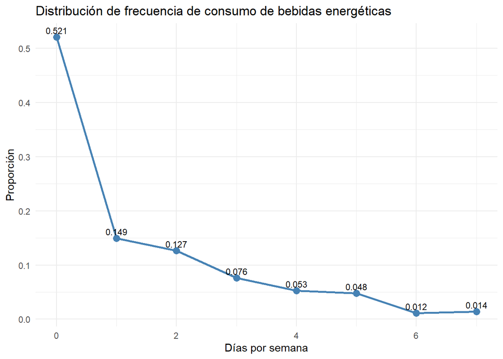

La mayoría de los estudiantes **no consume bebidas energéticas** (Moda = 0, Mediana = 0 días/semana). Sin embargo, la Media de **1.25 días/semana** revela que quienes sí consumen lo hacen con frecuencia considerable. El CV de **136.9%** indica altísima variabilidad: la distribución es asimétrica positiva con cola larga hacia la derecha, donde el 52.1% no consume nunca y solo el 1.4% consume los 7 días de la semana.

### 3.1.2 Horas de sueño por noche (HorasSuenio) — Cuantitativa continua

Descriptores — HorasSuenio

| n | Media | Mediana | DE | Asimetria | Curtosis |
| --- | --- | --- | --- | --- | --- |
| 1172 | 6.34 | 6 | 1.37 | 0.264 | 3.572 |

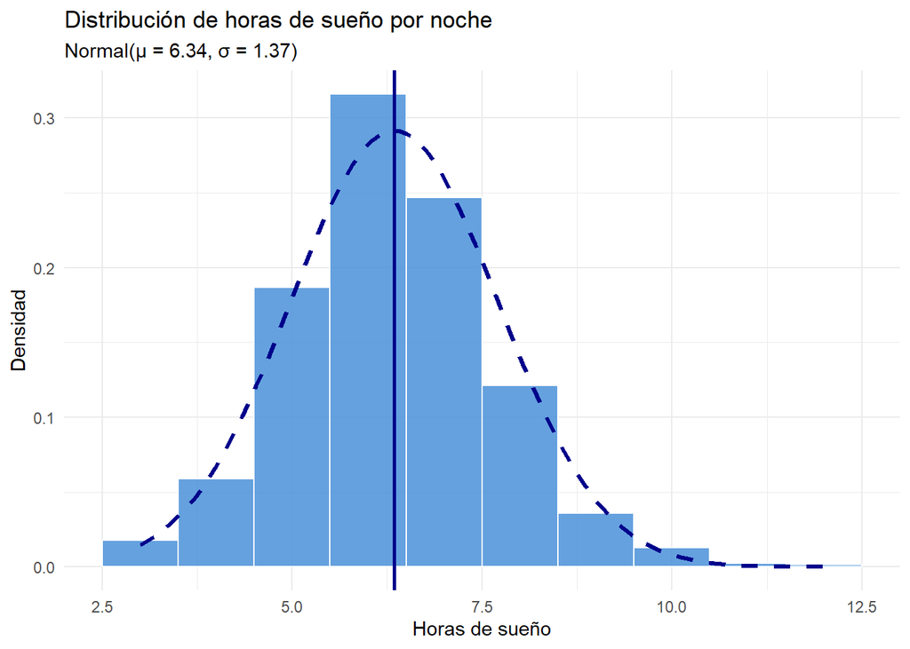

Los estudiantes duermen en promedio **6.34 horas** por noche (Mediana = 6 h, DE = 1.37). La proximidad entre media y mediana, junto con la asimetría de 0.26 (≈0) y la curtosis de 3.57 (≈3), confirman que las horas de sueño siguen una distribución aproximadamente Normal, lo que justifica su modelado en la sección IV.

### 3.1.3 Calidad de sueño autopercibida (CalidadSuenio) — Cualitativa ordinal

Distribución — CalidadSuenio

| Categoría | Frecuencia | Proporción |
| --- | --- | --- |
| Muy mala | 70 | 0.0587 |
| Mala | 247 | 0.2072 |
| Regular | 577 | 0.4841 |
| Buena | 239 | 0.2005 |
| Muy buena | 59 | 0.0495 |

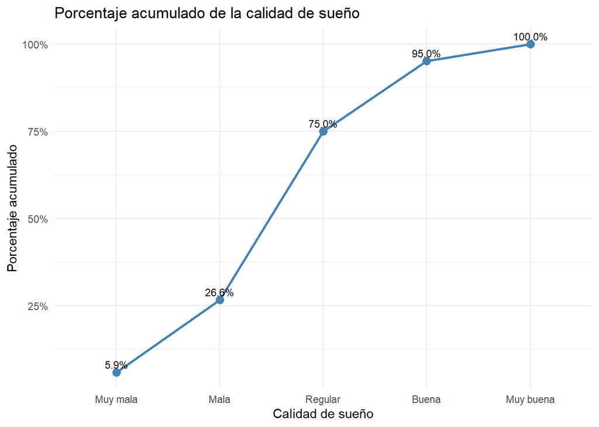

La categoría modal es **Regular** (≈49%). Sumando Mala y Muy mala, más del **26%** de los estudiantes reporta sueño deficiente.

### 3.1.4 Tipo de actividad física (ActividadFisica) — Cualitativa nominal

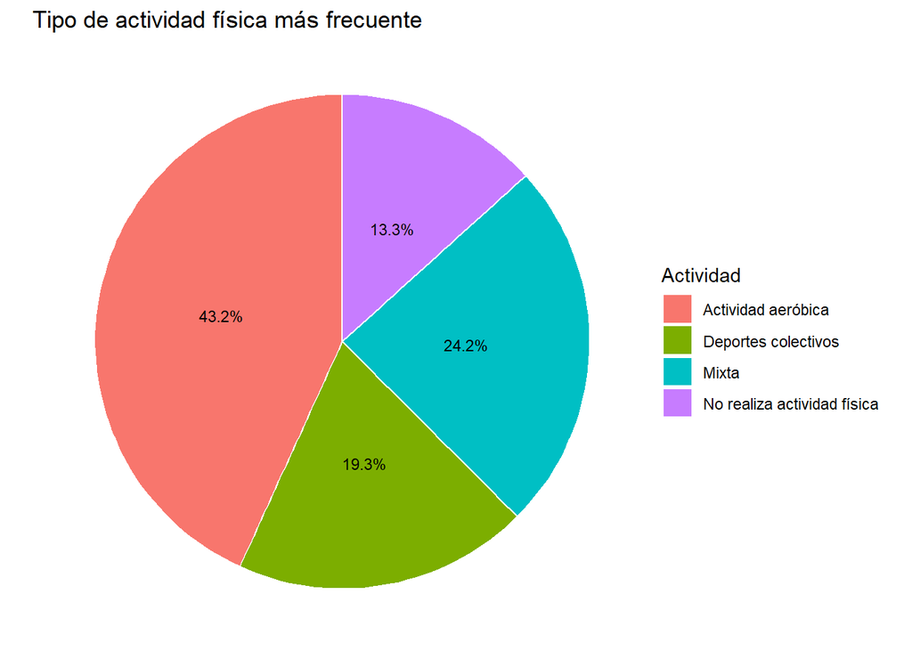

La **actividad aeróbica** es la más común (**43%**), seguida de actividad mixta (**24.2%**) y deportes colectivos (**19.3%**). Un **13.3%** no realiza ningún tipo de actividad física, cifra relevante en el contexto del bienestar estudiantil. No se registraron casos de actividad anaeróbica exclusiva en la muestra.

## 3.2 III.2 Análisis de interacción

### 3.2.1 Par numérico-numérico: HorasSuenio vs HorasEjercicio

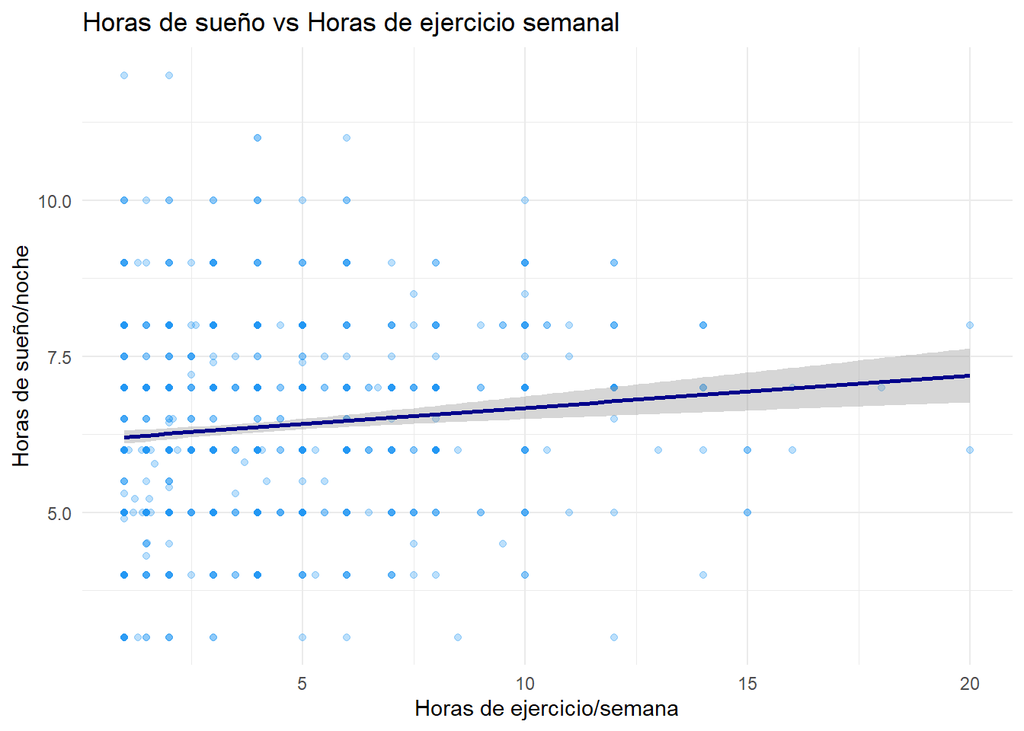

No se observa una tendencia lineal clara entre ejercicio y sueño. La nube de puntos está dispersa, lo que sugiere relación débil entre ambas variables continuas.

### 3.2.2 Par categórico-categórico: CalidadSuenio vs Estres

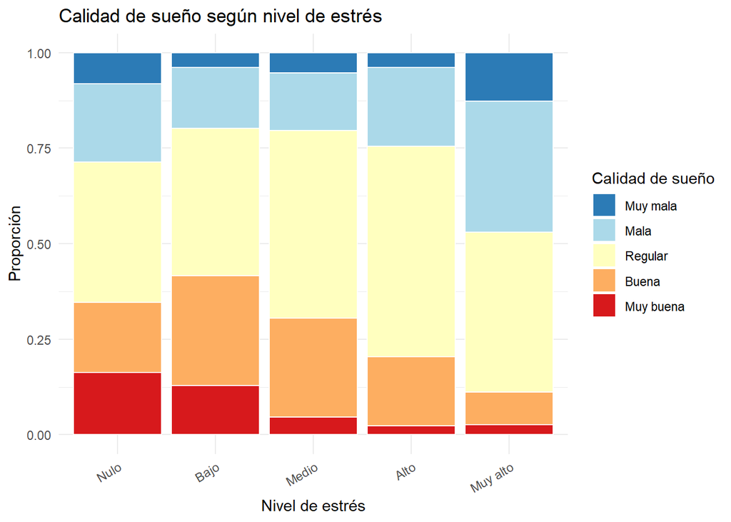

### 3.2.3 Par categórico-numérico: CalidadSuenio vs HorasSuenio

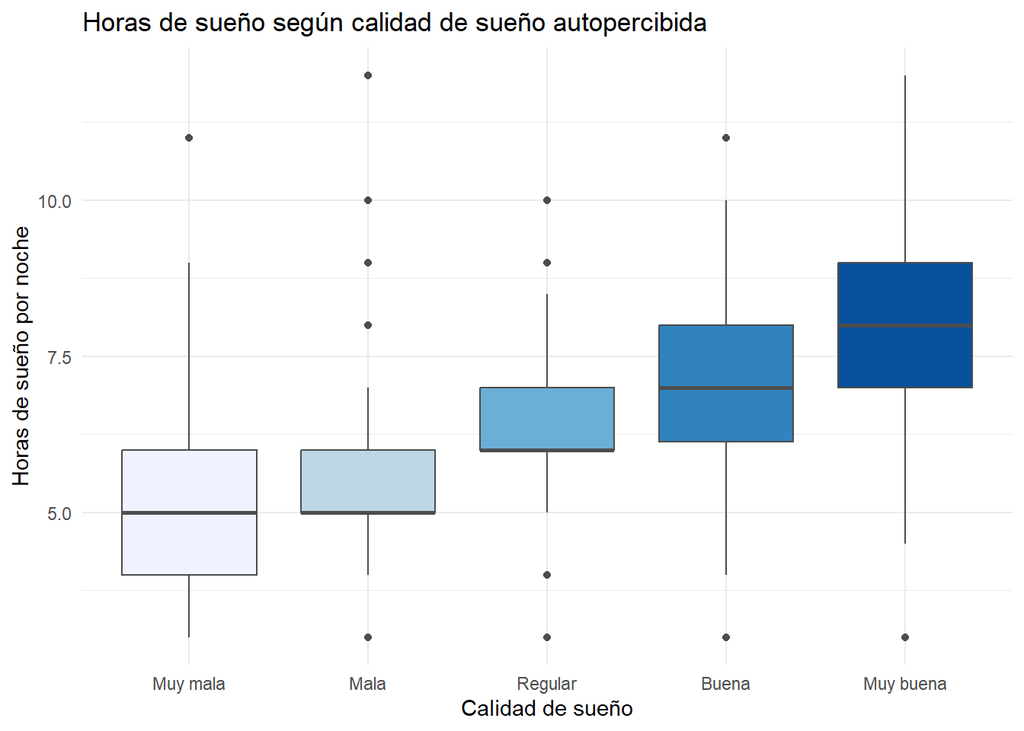

Los estudiantes con mejor calidad de sueño autopercibida tienden a dormir más horas. La mediana aumenta progresivamente de Muy mala a Muy buena, confirmando coherencia entre la percepción subjetiva y las horas reales de descanso.

# 4 IV. Análisis probabilístico

## 4.1 IV.1 Probabilidad empírica

### 4.1.1 Variable 1 — Frecuencia de consumo de bebidas energéticas

$EA_1$: Seleccionar una persona al azar y observar cuántos días por semana consume bebidas energéticas.

$$\Omega_{EA_1} = \{0,\ 1,\ 2,\ 3,\ 4,\ 5,\ 6,\ 7\}$$

Probabilidades empíricas — FrecBebida

| Días/semana | Frecuencia | P(Eᵢ) |
| --- | --- | --- |
| 0 | 621 | 0.5210 |
| 1 | 178 | 0.1493 |
| 2 | 151 | 0.1267 |
| 3 | 91 | 0.0763 |
| 4 | 63 | 0.0529 |
| 5 | 57 | 0.0478 |
| 6 | 14 | 0.0117 |
| 7 | 17 | 0.0143 |

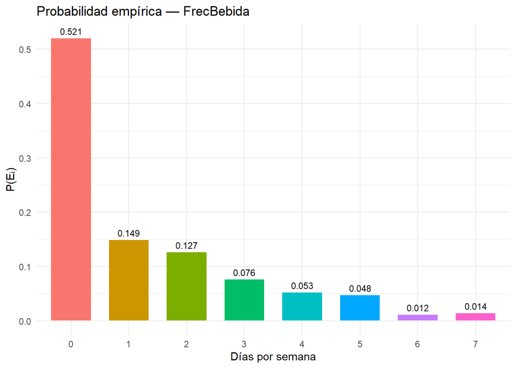

```r
n_v1 <- sum(!is.na(DF_seccion$FrecBebida))
P_E1 <- sum(DF_seccion$FrecBebida == 0, na.rm=TRUE) / n_v1
P_E8 <- sum(DF_seccion$FrecBebida == 7, na.rm=TRUE) / n_v1
cat("P(0 días) =", round(P_E1,4), "| P(7 días) =", round(P_E8,4),
    "| Suma =", round(sum(v1_tabla$P),4), "\n")
```

```
P(0 días) = 0.521 | P(7 días) = 0.0143 | Suma = 1
```

### 4.1.2 Variable 2 — Calidad de sueño autopercibida

$EA_2$: Seleccionar una persona al azar y observar su calidad de sueño autopercibida.

$$\Omega_{EA_2} = \{\text{Muy mala},\ \text{Mala},\ \text{Regular},\ \text{Buena},\ \text{Muy buena}\}$$

Probabilidades empíricas — CalidadSuenio

| Categoría | Frecuencia | P(Eᵢ) |
| --- | --- | --- |
| Muy mala | 70 | 0.0587 |
| Mala | 247 | 0.2072 |
| Regular | 577 | 0.4841 |
| Buena | 239 | 0.2005 |
| Muy buena | 59 | 0.0495 |

```r
cs <- as.character(DF_seccion$CalidadSuenio)
n_v2    <- sum(!is.na(cs))
P_reg   <- sum(cs == "Regular",  na.rm=TRUE) / n_v2
P_def   <- sum(cs %in% c("Muy mala","Mala"), na.rm=TRUE) / n_v2
cat("P(Regular) =", round(P_reg,4), "| P(Mala o Muy mala) =", round(P_def,4), "\n")
```

```
P(Regular) = 0.4841 | P(Mala o Muy mala) = 0.2659
```

La categoría Regular concentra **≈48.4%** de las observaciones. La probabilidad de percepción de sueño deficiente (Mala o Muy mala) es **0.266**.

## 4.2 IV.2 Probabilidad condicional

Se definen dos eventos:

- $E_1$: El estudiante **no consume bebidas energéticas** (FrecBebida = 0)
- $E_2$: El estudiante reporta calidad de sueño **Regular, Mala o Muy mala**

```r
DF_cond <- DF_seccion %>%
  filter(!is.na(FrecBebida), !is.na(CalidadSuenio)) %>%
  mutate(
    E1 = ifelse(FrecBebida == 0, "No consume", "Consume"),
    E2 = ifelse(as.character(CalidadSuenio) %in% c("Muy mala","Mala","Regular"),
                "Sueño regular o peor", "Sueño bueno o muy bueno")
  )

n_cond <- nrow(DF_cond)
P_E1   <- sum(DF_cond$E1 == "No consume") / n_cond
P_E2   <- sum(DF_cond$E2 == "Sueño regular o peor") / n_cond
P_int  <- sum(DF_cond$E1 == "No consume" & DF_cond$E2 == "Sueño regular o peor") / n_cond
P_E2c  <- 1 - P_E2
P_E1_E2  <- P_int / P_E2
P_E2_E1  <- P_int / P_E1
P_E1_E2c <- sum(DF_cond$E1=="No consume" & DF_cond$E2=="Sueño bueno o muy bueno") /
             sum(DF_cond$E2=="Sueño bueno o muy bueno")

cat("P(E1) =", round(P_E1,4), "| P(E2) =", round(P_E2,4), "\n")
```

```
P(E1) = 0.521 | P(E2) = 0.75
```

```r
cat("P(E1 ∩ E2) =", round(P_int,4), "| P(E1)·P(E2) =", round(P_E1*P_E2,4), "\n")
```

```
P(E1 ∩ E2) = 0.3935 | P(E1)·P(E2) = 0.3907
```

```r
cat("P(E1|E2) =", round(P_E1_E2,4), "| P(E2|E1) =", round(P_E2_E1,4), "\n")
```

```
P(E1|E2) = 0.5246 | P(E2|E1) = 0.7552
```

```r
if (round(P_int,4) != round(P_E1*P_E2,4)) cat("Los eventos son DEPENDIENTES\n")
```

```
Los eventos son DEPENDIENTES
```

```r
Bayes <- (P_E1_E2 * P_E2) / ((P_E1_E2 * P_E2) + (P_E1_E2c * P_E2c))
cat("T. Bayes P(E2|E1) =", round(Bayes,4))
```

```
T. Bayes P(E2|E1) = 0.7552
```

```r
if (round(Bayes,4) == round(P_E2_E1,4)) cat(" ✓ Verificado\n")
```

```
 ✓ Verificado
```

```r
tabla_cont <- table(DF_cond$E1, DF_cond$E2)
n_total <- sum(tabla_cont)

# Crear tabla con márgenes
tabla_margins <- addmargins(tabla_cont)

# Crear tabla de proporciones
tabla_prop <- prop.table(tabla_cont)
tabla_prop_marg <- addmargins(tabla_prop)

# Mostrar ambas tablas
cat("TABLA 1: Frecuencias Absolutas\n")
```

```
TABLA 1: Frecuencias Absolutas
```

```r
print(tabla_margins)
```

```
             Sueño bueno o muy bueno Sueño regular o peor  Sum
  Consume                        146                  425  571
  No consume                     152                  469  621
  Sum                            298                  894 1192
```

```r
cat("\n")
```

```r
cat("TABLA 2: Frecuencias Relativas (Proporciones)\n")
```

```
TABLA 2: Frecuencias Relativas (Proporciones)
```

```r
print(round(tabla_prop_marg, 4))
```

```
             Sueño bueno o muy bueno Sueño regular o peor    Sum
  Consume                     0.1225               0.3565 0.4790
  No consume                  0.1275               0.3935 0.5210
  Sum                         0.2500               0.7500 1.0000
```

```r
# Crear tabla presentable para el documento
# Usar directamente la tabla que ya existe
tabla_display <- data.frame(
  " " = c("No consume", "Consume", "Total"),
  "Sueño regular o peor" = c(
    tabla_cont["No consume", "Sueño regular o peor"],
    tabla_cont["Consume", "Sueño regular o peor"],
    sum(tabla_cont[, "Sueño regular o peor"])
  ),
  "Sueño bueno o muy bueno" = c(
    tabla_cont["No consume", "Sueño bueno o muy bueno"],
    tabla_cont["Consume", "Sueño bueno o muy bueno"],
    sum(tabla_cont[, "Sueño bueno o muy bueno"])
  ),
  "Total" = c(
    round(sum(tabla_cont["No consume", ]), 2),
    round(sum(tabla_cont["Consume", ]), 2),
    nrow(DF_cond)
  ),
  check.names = FALSE
)

kable(tabla_display,
      caption = "Tabla de contingencia 2×2: Frecuencias absolutas para eventos E₁ y E₂")
```

Tabla de contingencia 2×2: Frecuencias absolutas para eventos E₁ y E₂

|  | Sueño regular o peor | Sueño bueno o muy bueno | Total |
| --- | --- | --- | --- |
| No consume | 469 | 152 | 621 |
| Consume | 425 | 146 | 571 |
| Total | 894 | 298 | 1192 |

Dado que $P(E_1 \cap E_2) = 0.3935 \neq P(E_1) \cdot P(E_2) = 0.3907$, los eventos son **dependientes**: el consumo de bebidas energéticas y la calidad de sueño percibida no son independientes. La probabilidad condicional $P(E_2|E_1) = 0.7552$ indica que el **75.5% de quienes no consumen** bebidas energéticas reporta calidad de sueño Regular o peor, valor ligeramente superior a la probabilidad marginal $P(E_2) = 0.75$. Esto sugiere que evitar el consumo no garantiza mejor calidad de sueño, y que otros factores como el estrés tienen mayor influencia. El Teorema de Bayes verifica el resultado ($P(E_2|E_1) = 0.7552$ ✓).

## 4.3 IV.3 Variables aleatorias

### 4.3.1 Variable Discreta 1 — $X \sim \text{Geom}(p)$

**Variable de estudio:** FrecBebida (días/semana que consume bebidas energéticas)

**Caso:** ¿Cuántos estudiantes deben seleccionarse hasta encontrar al **primer consumidor** de bebidas energéticas?

$$X: \text{Nº de estudiantes seleccionados hasta el primer consumidor} \quad X \sim \text{Geom}(p)$$

```r
cat("p =", round(p_consume,4), "\n")
```

```
p = 0.479
```

```r
E_X1 <- 1/p_consume; V_X1 <- (1-p_consume)/p_consume^2; SD_X1 <- sqrt(V_X1)
cat("E(X) = 1/p =", round(E_X1,4), "| V(X) =", round(V_X1,4), "| SD(X) =", round(SD_X1,4),"\n")
```

```
E(X) = 1/p = 2.0876 | V(X) = 2.2704 | SD(X) = 1.5068
```

```r
k1 <- 3; P_X3 <- dgeom(k1-1, prob=p_consume)
lim1 <- 5; P_Xleq5 <- pgeom(lim1-1, prob=p_consume)
cat("P(X=3) =", round(P_X3,4), "| P(X≤5) =", round(P_Xleq5,4), "\n")
```

```
P(X=3) = 0.13 | P(X≤5) = 0.9616
```

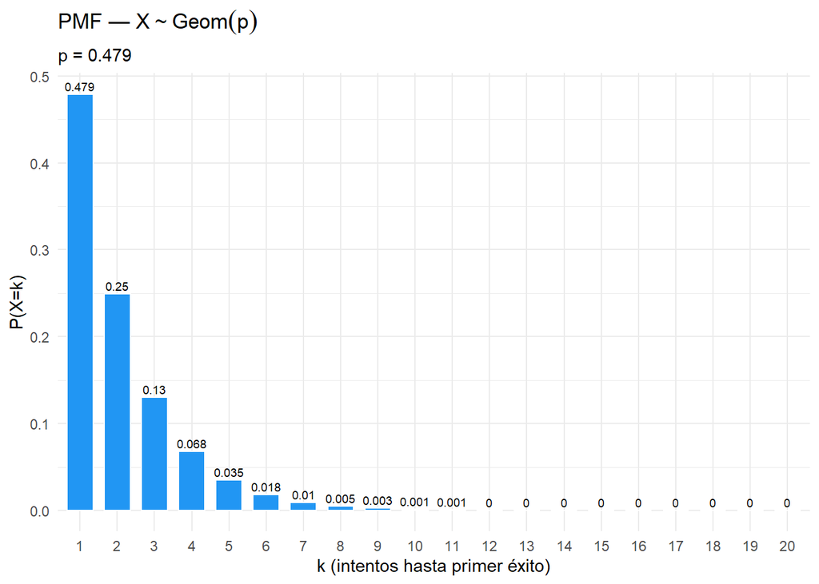

Con $p = 0.479$, en promedio se necesitan **2.1 estudiantes** para encontrar al primer consumidor. $P(X=3) = 0.13$ y $P(X \leq 5) = 0.9616$: en el 96% de los casos se encuentra al primer consumidor dentro de los primeros 5 intentos.

### 4.3.2 Variable Discreta 2 — $Y \sim \text{Binomial}(10, p)$

**Variable de estudio:** CalidadSuenio (categorías Mala/Muy mala)

**Caso:** En un grupo de **10 estudiantes** elegidos al azar, ¿cuántos reportan calidad de sueño deficiente (Mala o Muy mala)?

$$Y: \text{Nº de estudiantes con sueño deficiente en un grupo de 10} \quad Y \sim \text{Binom}(10, p)$$

```r
cat("p =", round(p_mal_suenio,4), "\n")
```

```
p = 0.2659
```

```r
n_b <- 10
E_Y <- n_b*p_mal_suenio; V_Y <- n_b*p_mal_suenio*(1-p_mal_suenio); SD_Y <- sqrt(V_Y)
cat("E(Y) = n·p =", round(E_Y,4), "| V(Y) =", round(V_Y,4), "| SD(Y) =", round(SD_Y,4),"\n")
```

```
E(Y) = n·p = 2.6594 | V(Y) = 1.9522 | SD(Y) = 1.3972
```

```r
k2 <- 2; P_Y2 <- dbinom(k2,n_b,p_mal_suenio)
lim2 <- 3; P_Yleq3 <- pbinom(lim2,n_b,p_mal_suenio)
cat("P(Y=2) =", round(P_Y2,4), "| P(Y≤3) =", round(P_Yleq3,4), "\n")
```

```
P(Y=2) = 0.2683 | P(Y≤3) = 0.7375
```

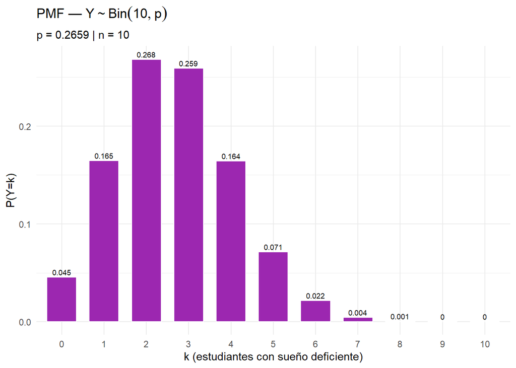

Con $p = 0.2659$, se esperan en promedio **2.66 estudiantes** con sueño deficiente por grupo de 10. $P(Y=2) = 0.2683$ es el valor más probable, y $P(Y \leq 3) = 0.7375$: en el 74% de los grupos de 10 habrá a lo mucho 3 estudiantes con sueño deficiente.

### 4.3.3 Variable Continua 1 — $Z \sim \text{Exp}(\lambda)$

**Variable de estudio:** HorasEjercicio (horas de actividad física por semana)

**Caso de estudio:** Modelar la distribución de horas de ejercicio físico semanal para analizar patrones de actividad en estudiantes universitarios. Esta información es relevante para diseñar intervenciones de bienestar que promuevan estilos de vida más activos.

```r
cat("n =", length(ejercicio_vec), "| Media =", round(mu_ej,4),
    "| SD =", round(sd_ej,4), "| Asimetría =", round(skewness(ejercicio_vec),4),"\n")
```

```
n = 1186 | Media = 3.6793 | SD = 2.9931 | Asimetría = 1.6282
```

```r
cat("λ =", round(lam_ej,4), "| E(Z) = 1/λ =", round(1/lam_ej,4),
    "| V(Z) = 1/λ² =", round(1/lam_ej^2,4), "\n")
```

```
λ = 0.2718 | E(Z) = 1/λ = 3.6793 | V(Z) = 1/λ² = 13.5369
```

Por los parámetros de asimetría y demás outputs parece no ser exponencial teóricamente. Procedemos a comparar con la distribución Gamma:

```r
# Filtrar los ceros si es necesario (la Gamma estricta no acepta ceros exactos)
datos_filtrados <- DF$HorasEjercicio[DF$HorasEjercicio > 0 & !is.na(DF$HorasEjercicio)]

# Ajustar ambas distribuciones
fit_exp <- fitdist(datos_filtrados, "exp")
fit_gamma <- fitdist(datos_filtrados, "gamma")

# Comparar AIC
summary(fit_exp)$aic
```

```
[1] 5464.031
```

```r
summary(fit_gamma)$aic
```

```
[1] 5253.335
```

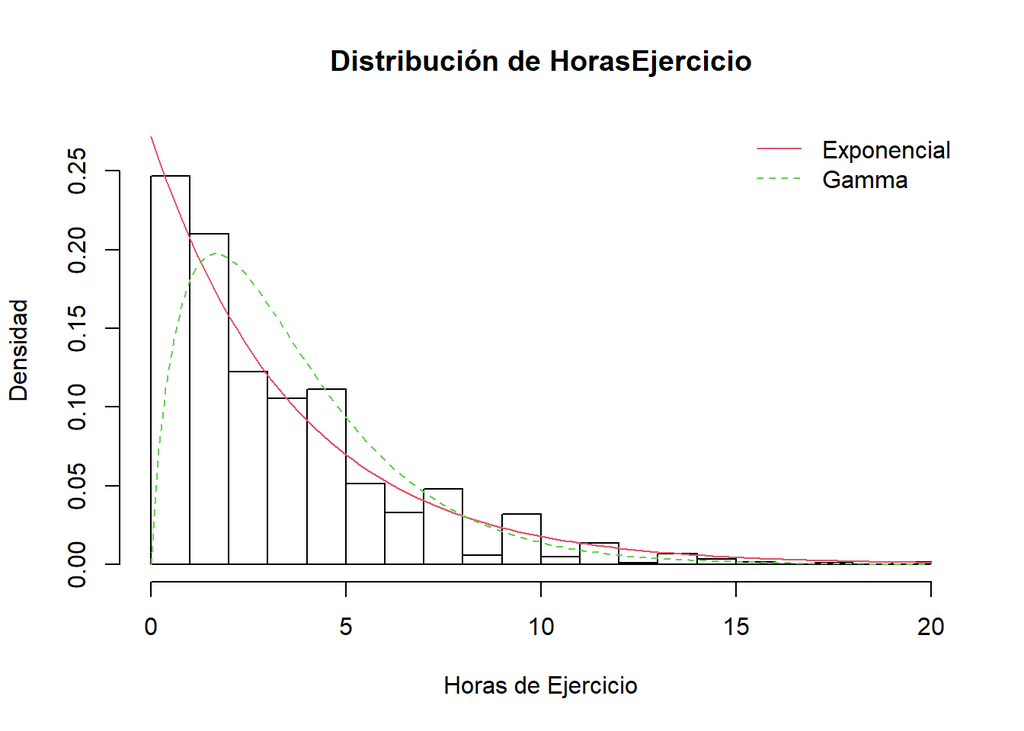

```r
# Graficar la comparación real vs teórica
plotlegend <- c("Exponencial", "Gamma")

# 2. Graficamos modificando los saltos (breaks) directamente
# Usamos addlegend = FALSE para evitar que R se rompa
denscomp(list(fit_exp, fit_gamma),
         main = "Distribución de HorasEjercicio",
         xlab = "Horas de Ejercicio",
         ylab = "Densidad",
         xlim = c(0, 20),
         breaks = seq(0, 20, by = 1), # <- Aquí defines los saltos de 1 en 1 hora
         addlegend = FALSE)           # <- Desactivamos la leyenda automática
# 3. Agregamos la leyenda de forma manual justo abajo
legend("topright",
       legend = plotlegend,
       col = 2:3,   # Colores por defecto que usa denscomp (rojo y verde)
       lty = 1:2,   # Tipos de línea por defecto (continua y discontinua)
       bty = "n")   # "n" elimina el recuadro gris de la leyenda
```

```r
P_Z5 <- 1 - pexp(5, rate=lam_ej)
cat("P(Z > 5) =", round(P_Z5,4), "=>", round(P_Z5*100,1), "% realiza más de 5 hrs/semana\n")
```

```
P(Z > 5) = 0.2569 => 25.7 % realiza más de 5 hrs/semana
```

El **25.7%** de los estudiantes realiza más de 5 horas de ejercicio semanal (**74.3% realiza 5 horas o menos**), lo que es consistente con la cola derecha de la distribución Exponencial: la gran mayoría se concentra en valores bajos con pocos casos en valores extremos.

### 4.3.4 Variable Continua 2 — $W \sim \text{Normal}(\mu, \sigma)$

**Variable de estudio:** HorasSuenio (horas de sueño por noche)

```r
cat("n =", length(suenio_vec), "| μ =", round(mu_su,4), "| σ =", round(sd_su,4),
    "| Asimetría =", round(skewness(suenio_vec),4), "| Curtosis =", round(kurtosis(suenio_vec),4),"\n")
```

```
n = 1172 | μ = 6.3444 | σ = 1.3698 | Asimetría = 0.2641 | Curtosis = 3.5724
```

```r
cat("E(W) = μ =", round(mu_su,4), "| V(W) = σ² =", round(sd_su^2,4),
    "| SD(W) = σ =", round(sd_su,4), "\n")
```

```
E(W) = μ = 6.3444 | V(W) = σ² = 1.8764 | SD(W) = σ = 1.3698
```

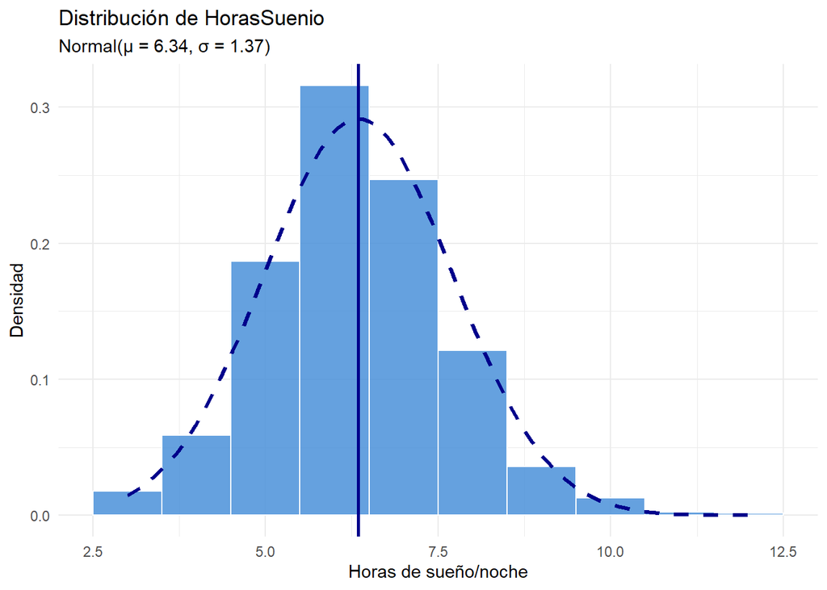

La asimetría de **0.26** (≈0) y curtosis de **3.57** (≈3) validan la aproximación Normal. Con $W \sim \text{Normal}(6.34, 1.37)$, la mayoría duerme entre 5 y 7.7 horas (μ ± σ).

```r
P_rango <- pnorm(8,mu_su,sd_su) - pnorm(6,mu_su,sd_su)
cat("P(6 ≤ W ≤ 8) =", round(P_rango,4), "→", round(P_rango*100,1),
    "% de los estudiantes duerme entre 6 y 8 horas\n")
```

```
P(6 ≤ W ≤ 8) = 0.4859 → 48.6 % de los estudiantes duerme entre 6 y 8 horas
```

La probabilidad de dormir en el **rango recomendado (6–8 horas)** es $P(6 \leq W \leq 8) = 0.4859$, indicando que el **48.6%** de la sección descansa una cantidad adecuada.

# 5 V. Conclusiones